| title: “R Notebook” |
| --- |
| output: |
| pdf_document: |
| latex_engine: xelatex |
| html_notebook: default |
| html_document: default |
| mainfont: NanumGothic |

# import libraray

```r
library(tidyverse)
library(nycflights13)
library(quantmod)
```

# Textbook 5.2.4

## Problem 1

```r
filter(flights, arr_delay >= 120)
```

```
## # A tibble: 10,200 × 19
##     year month   day dep_time sched_de…¹ dep_d…² arr_t…³ sched…⁴ arr_d…⁵ carrier
##    <int> <int> <int>    <int>      <int>   <dbl>   <int>   <int>   <dbl> <chr>
##  1  2013     1     1      811        630     101    1047     830     137 MQ
##  2  2013     1     1      848       1835     853    1001    1950     851 MQ
##  3  2013     1     1      957        733     144    1056     853     123 UA
##  4  2013     1     1     1114        900     134    1447    1222     145 UA
##  5  2013     1     1     1505       1310     115    1638    1431     127 EV
##  6  2013     1     1     1525       1340     105    1831    1626     125 B6
##  7  2013     1     1     1549       1445      64    1912    1656     136 EV
##  8  2013     1     1     1558       1359     119    1718    1515     123 EV
##  9  2013     1     1     1732       1630      62    2028    1825     123 EV
## 10  2013     1     1     1803       1620     103    2008    1750     138 MQ
## # … with 10,190 more rows, 9 more variables: flight <int>, tailnum <chr>,
## #   origin <chr>, dest <chr>, air_time <dbl>, distance <dbl>, hour <dbl>,
## #   minute <dbl>, time_hour <dttm>, and abbreviated variable names
## #   ¹sched_dep_time, ²dep_delay, ³arr_time, ⁴sched_arr_time, ⁵arr_delay
```

```r
filter(flights, dest %in% c("IAH", "HOU"))
```

```
## # A tibble: 9,313 × 19
##     year month   day dep_time sched_de…¹ dep_d…² arr_t…³ sched…⁴ arr_d…⁵ carrier
##    <int> <int> <int>    <int>      <int>   <dbl>   <int>   <int>   <dbl> <chr>
##  1  2013     1     1      517        515       2     830     819      11 UA
##  2  2013     1     1      533        529       4     850     830      20 UA
##  3  2013     1     1      623        627      -4     933     932       1 UA
##  4  2013     1     1      728        732      -4    1041    1038       3 UA
##  5  2013     1     1      739        739       0    1104    1038      26 UA
##  6  2013     1     1      908        908       0    1228    1219       9 UA
##  7  2013     1     1     1028       1026       2    1350    1339      11 UA
##  8  2013     1     1     1044       1045      -1    1352    1351       1 UA
##  9  2013     1     1     1114        900     134    1447    1222     145 UA
## 10  2013     1     1     1205       1200       5    1503    1505      -2 UA
## # … with 9,303 more rows, 9 more variables: flight <int>, tailnum <chr>,
## #   origin <chr>, dest <chr>, air_time <dbl>, distance <dbl>, hour <dbl>,
## #   minute <dbl>, time_hour <dttm>, and abbreviated variable names
## #   ¹sched_dep_time, ²dep_delay, ³arr_time, ⁴sched_arr_time, ⁵arr_delay
```

```r
filter(flights, carrier %in% c("UA", "AA", "DL"))
```

```
## # A tibble: 139,504 × 19
##     year month   day dep_time sched_de…¹ dep_d…² arr_t…³ sched…⁴ arr_d…⁵ carrier
##    <int> <int> <int>    <int>      <int>   <dbl>   <int>   <int>   <dbl> <chr>
##  1  2013     1     1      517        515       2     830     819      11 UA
##  2  2013     1     1      533        529       4     850     830      20 UA
##  3  2013     1     1      542        540       2     923     850      33 AA
##  4  2013     1     1      554        600      -6     812     837     -25 DL
##  5  2013     1     1      554        558      -4     740     728      12 UA
##  6  2013     1     1      558        600      -2     753     745       8 AA
##  7  2013     1     1      558        600      -2     924     917       7 UA
##  8  2013     1     1      558        600      -2     923     937     -14 UA
##  9  2013     1     1      559        600      -1     941     910      31 AA
## 10  2013     1     1      559        600      -1     854     902      -8 UA
## # … with 139,494 more rows, 9 more variables: flight <int>, tailnum <chr>,
## #   origin <chr>, dest <chr>, air_time <dbl>, distance <dbl>, hour <dbl>,
## #   minute <dbl>, time_hour <dttm>, and abbreviated variable names
## #   ¹sched_dep_time, ²dep_delay, ³arr_time, ⁴sched_arr_time, ⁵arr_delay
```

```r
filter(flights, month %in% c(7:9))
```

```
## # A tibble: 86,326 × 19
##     year month   day dep_time sched_de…¹ dep_d…² arr_t…³ sched…⁴ arr_d…⁵ carrier
##    <int> <int> <int>    <int>      <int>   <dbl>   <int>   <int>   <dbl> <chr>
##  1  2013     7     1        1       2029     212     236    2359     157 B6
##  2  2013     7     1        2       2359       3     344     344       0 B6
##  3  2013     7     1       29       2245     104     151       1     110 B6
##  4  2013     7     1       43       2130     193     322      14     188 B6
##  5  2013     7     1       44       2150     174     300     100     120 AA
##  6  2013     7     1       46       2051     235     304    2358     186 B6
##  7  2013     7     1       48       2001     287     308    2305     243 VX
##  8  2013     7     1       58       2155     183     335      43     172 B6
##  9  2013     7     1      100       2146     194     327      30     177 B6
## 10  2013     7     1      100       2245     135     337     135     122 B6
## # … with 86,316 more rows, 9 more variables: flight <int>, tailnum <chr>,
## #   origin <chr>, dest <chr>, air_time <dbl>, distance <dbl>, hour <dbl>,
## #   minute <dbl>, time_hour <dttm>, and abbreviated variable names
## #   ¹sched_dep_time, ²dep_delay, ³arr_time, ⁴sched_arr_time, ⁵arr_delay
```

```r
filter(flights, arr_delay >= 120, dep_delay<=0)
```

```
## # A tibble: 29 × 19
##     year month   day dep_time sched_de…¹ dep_d…² arr_t…³ sched…⁴ arr_d…⁵ carrier
##    <int> <int> <int>    <int>      <int>   <dbl>   <int>   <int>   <dbl> <chr>
##  1  2013     1    27     1419       1420      -1    1754    1550     124 MQ
##  2  2013    10     7     1350       1350       0    1736    1526     130 EV
##  3  2013    10     7     1357       1359      -2    1858    1654     124 AA
##  4  2013    10    16      657        700      -3    1258    1056     122 B6
##  5  2013    11     1      658        700      -2    1329    1015     194 VX
##  6  2013     3    18     1844       1847      -3      39    2219     140 UA
##  7  2013     4    17     1635       1640      -5    2049    1845     124 MQ
##  8  2013     4    18      558        600      -2    1149     850     179 AA
##  9  2013     4    18      655        700      -5    1213     950     143 AA
## 10  2013     5    22     1827       1830      -3    2217    2010     127 MQ
## # … with 19 more rows, 9 more variables: flight <int>, tailnum <chr>,
## #   origin <chr>, dest <chr>, air_time <dbl>, distance <dbl>, hour <dbl>,
## #   minute <dbl>, time_hour <dttm>, and abbreviated variable names
## #   ¹sched_dep_time, ²dep_delay, ³arr_time, ⁴sched_arr_time, ⁵arr_delay
```

```r
filter(flights, arr_delay >= 60, arr_delay == dep_delay)
```

```
## # A tibble: 488 × 19
##     year month   day dep_time sched_de…¹ dep_d…² arr_t…³ sched…⁴ arr_d…⁵ carrier
##    <int> <int> <int>    <int>      <int>   <dbl>   <int>   <int>   <dbl> <chr>
##  1  2013     1     3      851        700     111    1206    1015     111 AA
##  2  2013     1     6     1356       1205     111    1536    1345     111 MQ
##  3  2013     1    14     1535       1425      70    1740    1630      70 EV
##  4  2013     1    16     1256       1025     151    1502    1231     151 EV
##  5  2013     1    16     1941       1745     116    2216    2020     116 MQ
##  6  2013     1    16     2322       2130     112     217      25     112 B6
##  7  2013     1    17      801        600     121    1002     801     121 EV
##  8  2013     1    17     2031       1905      86    2239    2113      86 EV
##  9  2013     1    18     1603       1330     153    1838    1605     153 DL
## 10  2013     1    18     1827       1600     147    2152    1925     147 AA
## # … with 478 more rows, 9 more variables: flight <int>, tailnum <chr>,
## #   origin <chr>, dest <chr>, air_time <dbl>, distance <dbl>, hour <dbl>,
## #   minute <dbl>, time_hour <dttm>, and abbreviated variable names
## #   ¹sched_dep_time, ²dep_delay, ³arr_time, ⁴sched_arr_time, ⁵arr_delay
```

```r
filter(flights, dep_time <= 600 | dep_time == 2400 )
```

```
## # A tibble: 9,373 × 19
##     year month   day dep_time sched_de…¹ dep_d…² arr_t…³ sched…⁴ arr_d…⁵ carrier
##    <int> <int> <int>    <int>      <int>   <dbl>   <int>   <int>   <dbl> <chr>
##  1  2013     1     1      517        515       2     830     819      11 UA
##  2  2013     1     1      533        529       4     850     830      20 UA
##  3  2013     1     1      542        540       2     923     850      33 AA
##  4  2013     1     1      544        545      -1    1004    1022     -18 B6
##  5  2013     1     1      554        600      -6     812     837     -25 DL
##  6  2013     1     1      554        558      -4     740     728      12 UA
##  7  2013     1     1      555        600      -5     913     854      19 B6
##  8  2013     1     1      557        600      -3     709     723     -14 EV
##  9  2013     1     1      557        600      -3     838     846      -8 B6
## 10  2013     1     1      558        600      -2     753     745       8 AA
## # … with 9,363 more rows, 9 more variables: flight <int>, tailnum <chr>,
## #   origin <chr>, dest <chr>, air_time <dbl>, distance <dbl>, hour <dbl>,
## #   minute <dbl>, time_hour <dttm>, and abbreviated variable names
## #   ¹sched_dep_time, ²dep_delay, ³arr_time, ⁴sched_arr_time, ⁵arr_delay
```

## Problem 4

```r
NA^0
```

```
## [1] 1
```

```r
NA | TRUE
```

```
## [1] TRUE
```

```r
NA & FALSE
```

```
## [1] FALSE
```

```r
NA * 0
```

```
## [1] NA
```

NA는 알지 못하는 값을 의미한다. 따라서 NA는 어떤 숫자든지 가능하다. 그리고 r에서는 0과 무한을 포함한 모든 수의 0제곱은 1이다.`NA ^ 0` 는 NA를 알지 못하더라도 1이다. ‘|’연산자는 ’or’을 의미한다. ’or’은 하나라도 TRUE이면 식 전체가 TRUE가 된다. 그래서 NA값이 참이든 거짓이든 상관없이 한 값이 TRUE이므로 `NA | TRUE`는 TRUE이다.’&’연산자는 ’and’를 의미한다. ’and’는 오직 모든 값이 TRUE일 때만 TRUE가 된다. 그래서 NA값이 참이든 거짓이든 상관없이 한 값이 FALSE이므로 `NA & FALSE`는 FALSE이다. NA는 어떤 수든지 될 수 있다. NA의 값이 유한한 수라면, 수식의 값은 0이 될 것이다. 하지만, 만약 무한이라면 그 값은 NaN이 된다.

```r
Inf*0
```

```
## [1] NaN
```

# Textbook 5.3.1

## Problem 2

```r
arrange(flights, desc(dep_delay))
```

```
## # A tibble: 336,776 × 19
##     year month   day dep_time sched_de…¹ dep_d…² arr_t…³ sched…⁴ arr_d…⁵ carrier
##    <int> <int> <int>    <int>      <int>   <dbl>   <int>   <int>   <dbl> <chr>
##  1  2013     1     9      641        900    1301    1242    1530    1272 HA
##  2  2013     6    15     1432       1935    1137    1607    2120    1127 MQ
##  3  2013     1    10     1121       1635    1126    1239    1810    1109 MQ
##  4  2013     9    20     1139       1845    1014    1457    2210    1007 AA
##  5  2013     7    22      845       1600    1005    1044    1815     989 MQ
##  6  2013     4    10     1100       1900     960    1342    2211     931 DL
##  7  2013     3    17     2321        810     911     135    1020     915 DL
##  8  2013     6    27      959       1900     899    1236    2226     850 DL
##  9  2013     7    22     2257        759     898     121    1026     895 DL
## 10  2013    12     5      756       1700     896    1058    2020     878 AA
## # … with 336,766 more rows, 9 more variables: flight <int>, tailnum <chr>,
## #   origin <chr>, dest <chr>, air_time <dbl>, distance <dbl>, hour <dbl>,
## #   minute <dbl>, time_hour <dttm>, and abbreviated variable names
## #   ¹sched_dep_time, ²dep_delay, ³arr_time, ⁴sched_arr_time, ⁵arr_delay
```

가장 지연된 비행기는 HA51이다. 그 비행기는 tailnum이 N384HA이고 2013 1월 9일에 JFK에서 출발하여 HNL에 도착했다.

```r
arrange(flights, dep_delay)
```

```
## # A tibble: 336,776 × 19
##     year month   day dep_time sched_de…¹ dep_d…² arr_t…³ sched…⁴ arr_d…⁵ carrier
##    <int> <int> <int>    <int>      <int>   <dbl>   <int>   <int>   <dbl> <chr>
##  1  2013    12     7     2040       2123     -43      40    2352      48 B6
##  2  2013     2     3     2022       2055     -33    2240    2338     -58 DL
##  3  2013    11    10     1408       1440     -32    1549    1559     -10 EV
##  4  2013     1    11     1900       1930     -30    2233    2243     -10 DL
##  5  2013     1    29     1703       1730     -27    1947    1957     -10 F9
##  6  2013     8     9      729        755     -26    1002     955       7 MQ
##  7  2013    10    23     1907       1932     -25    2143    2143       0 EV
##  8  2013     3    30     2030       2055     -25    2213    2250     -37 MQ
##  9  2013     3     2     1431       1455     -24    1601    1631     -30 9E
## 10  2013     5     5      934        958     -24    1225    1309     -44 B6
## # … with 336,766 more rows, 9 more variables: flight <int>, tailnum <chr>,
## #   origin <chr>, dest <chr>, air_time <dbl>, distance <dbl>, hour <dbl>,
## #   minute <dbl>, time_hour <dttm>, and abbreviated variable names
## #   ¹sched_dep_time, ²dep_delay, ³arr_time, ⁴sched_arr_time, ⁵arr_delay
```

가장 빨리 떠난 비행기는 B697이다. 그 비행기는 tailnum이 N592JB이고 2013 12월 7일에 JFK에서 출발하여 DEN에 도착했다.

# Textbook 5.4.1

## Problem 1

```r
select(flights, dep_time, dep_delay, arr_time, arr_delay)
```

```
## # A tibble: 336,776 × 4
##    dep_time dep_delay arr_time arr_delay
##       <int>     <dbl>    <int>     <dbl>
##  1      517         2      830        11
##  2      533         4      850        20
##  3      542         2      923        33
##  4      544        -1     1004       -18
##  5      554        -6      812       -25
##  6      554        -4      740        12
##  7      555        -5      913        19
##  8      557        -3      709       -14
##  9      557        -3      838        -8
## 10      558        -2      753         8
## # … with 336,766 more rows
```

```r
select(flights, dep_time:arr_delay)
```

```
## # A tibble: 336,776 × 6
##    dep_time sched_dep_time dep_delay arr_time sched_arr_time arr_delay
##       <int>          <int>     <dbl>    <int>          <int>     <dbl>
##  1      517            515         2      830            819        11
##  2      533            529         4      850            830        20
##  3      542            540         2      923            850        33
##  4      544            545        -1     1004           1022       -18
##  5      554            600        -6      812            837       -25
##  6      554            558        -4      740            728        12
##  7      555            600        -5      913            854        19
##  8      557            600        -3      709            723       -14
##  9      557            600        -3      838            846        -8
## 10      558            600        -2      753            745         8
## # … with 336,766 more rows
```

```r
select(flights, 4:9)
```

```
## # A tibble: 336,776 × 6
##    dep_time sched_dep_time dep_delay arr_time sched_arr_time arr_delay
##       <int>          <int>     <dbl>    <int>          <int>     <dbl>
##  1      517            515         2      830            819        11
##  2      533            529         4      850            830        20
##  3      542            540         2      923            850        33
##  4      544            545        -1     1004           1022       -18
##  5      554            600        -6      812            837       -25
##  6      554            558        -4      740            728        12
##  7      555            600        -5      913            854        19
##  8      557            600        -3      709            723       -14
##  9      557            600        -3      838            846        -8
## 10      558            600        -2      753            745         8
## # … with 336,766 more rows
```

```r
select(flights, 4, 6, 7, 9)
```

```
## # A tibble: 336,776 × 4
##    dep_time dep_delay arr_time arr_delay
##       <int>     <dbl>    <int>     <dbl>
##  1      517         2      830        11
##  2      533         4      850        20
##  3      542         2      923        33
##  4      544        -1     1004       -18
##  5      554        -6      812       -25
##  6      554        -4      740        12
##  7      555        -5      913        19
##  8      557        -3      709       -14
##  9      557        -3      838        -8
## 10      558        -2      753         8
## # … with 336,766 more rows
```

```r
select(flights, starts_with("dep"), starts_with("arr"))
```

```
## # A tibble: 336,776 × 4
##    dep_time dep_delay arr_time arr_delay
##       <int>     <dbl>    <int>     <dbl>
##  1      517         2      830        11
##  2      533         4      850        20
##  3      542         2      923        33
##  4      544        -1     1004       -18
##  5      554        -6      812       -25
##  6      554        -4      740        12
##  7      555        -5      913        19
##  8      557        -3      709       -14
##  9      557        -3      838        -8
## 10      558        -2      753         8
## # … with 336,766 more rows
```

# Textbook 5.5.2

## Problem 1

```r
flights_minute <- mutate(flights, dep_time_minutes = dep_time %/% 100 * 60 + dep_time %% 100, sched_dep_time_minutes = sched_dep_time %/% 100 * 60 + sched_dep_time %% 100 )
flights_minute
```

```
## # A tibble: 336,776 × 21
##     year month   day dep_time sched_de…¹ dep_d…² arr_t…³ sched…⁴ arr_d…⁵ carrier
##    <int> <int> <int>    <int>      <int>   <dbl>   <int>   <int>   <dbl> <chr>
##  1  2013     1     1      517        515       2     830     819      11 UA
##  2  2013     1     1      533        529       4     850     830      20 UA
##  3  2013     1     1      542        540       2     923     850      33 AA
##  4  2013     1     1      544        545      -1    1004    1022     -18 B6
##  5  2013     1     1      554        600      -6     812     837     -25 DL
##  6  2013     1     1      554        558      -4     740     728      12 UA
##  7  2013     1     1      555        600      -5     913     854      19 B6
##  8  2013     1     1      557        600      -3     709     723     -14 EV
##  9  2013     1     1      557        600      -3     838     846      -8 B6
## 10  2013     1     1      558        600      -2     753     745       8 AA
## # … with 336,766 more rows, 11 more variables: flight <int>, tailnum <chr>,
## #   origin <chr>, dest <chr>, air_time <dbl>, distance <dbl>, hour <dbl>,
## #   minute <dbl>, time_hour <dttm>, dep_time_minutes <dbl>,
## #   sched_dep_time_minutes <dbl>, and abbreviated variable names
## #   ¹sched_dep_time, ²dep_delay, ³arr_time, ⁴sched_arr_time, ⁵arr_delay
```

## Problem 4

```r
flights_delay <- mutate(flights, dep_delay_rank = min_rank(desc(dep_delay)))
flights_delay <- arrange(flights_delay, dep_delay_rank)
flights_delay
```

```
## # A tibble: 336,776 × 20
##     year month   day dep_time sched_de…¹ dep_d…² arr_t…³ sched…⁴ arr_d…⁵ carrier
##    <int> <int> <int>    <int>      <int>   <dbl>   <int>   <int>   <dbl> <chr>
##  1  2013     1     9      641        900    1301    1242    1530    1272 HA
##  2  2013     6    15     1432       1935    1137    1607    2120    1127 MQ
##  3  2013     1    10     1121       1635    1126    1239    1810    1109 MQ
##  4  2013     9    20     1139       1845    1014    1457    2210    1007 AA
##  5  2013     7    22      845       1600    1005    1044    1815     989 MQ
##  6  2013     4    10     1100       1900     960    1342    2211     931 DL
##  7  2013     3    17     2321        810     911     135    1020     915 DL
##  8  2013     6    27      959       1900     899    1236    2226     850 DL
##  9  2013     7    22     2257        759     898     121    1026     895 DL
## 10  2013    12     5      756       1700     896    1058    2020     878 AA
## # … with 336,766 more rows, 10 more variables: flight <int>, tailnum <chr>,
## #   origin <chr>, dest <chr>, air_time <dbl>, distance <dbl>, hour <dbl>,
## #   minute <dbl>, time_hour <dttm>, dep_delay_rank <int>, and abbreviated
## #   variable names ¹sched_dep_time, ²dep_delay, ³arr_time, ⁴sched_arr_time,
## #   ⁵arr_delay
```

가장 지연된 10개의 비행기는 위와 같다.

## Problem 5

```r
1:3 + 1:10
```

```
## Warning in 1:3 + 1:10: 두 객체의 길이가 서로 배수관계에 있지 않습니다
```

```
##  [1]  2  4  6  5  7  9  8 10 12 11
```

‘longer object length is not a multiple of shorter object length ’라는 경고메시지와 함께’ 2 4 6 5 7 9 8 10 12 11’이 출력됩니다. 두 벡터를 더하기 위해 더 짧은 길이를 가진 벡터를 반복하여 더 긴 벡터와의 길이를 맞춥니다. 하지만 긴 벡터가 짧은 벡터의 배수가 아니므로 경고메세지가 나옵니다. 위 수식에서는 1:3이 3번 반복되어 이용되고 마지막으로 벡터의 첫번째 요소인 다시 사용되어 1:10과 더해졌습니다.

# Textbook 5.6.7

## Problem 5

```r
flights %>% group_by(carrier) %>% summarise(arr_delay = mean(arr_delay, na.rm = TRUE)) %>% arrange(desc(arr_delay))
```

```
## # A tibble: 16 × 2
##    carrier arr_delay
##    <chr>       <dbl>
##  1 F9         21.9
##  2 FL         20.1
##  3 EV         15.8
##  4 YV         15.6
##  5 OO         11.9
##  6 MQ         10.8
##  7 WN          9.65
##  8 B6          9.46
##  9 9E          7.38
## 10 UA          3.56
## 11 US          2.13
## 12 VX          1.76
## 13 DL          1.64
## 14 AA          0.364
## 15 HA         -6.92
## 16 AS         -9.93
```

carrier로 그룹화한후 지연시간의 평균을 구했을 때, 평균지연시간이 가장 큰 carrier은 F9이었습니다.

```r
flights %>% summarise(n_distinct(carrier), n_distinct(dest), n_distinct(origin))
```

```
## # A tibble: 1 × 3
##   `n_distinct(carrier)` `n_distinct(dest)` `n_distinct(origin)`
##                   <int>              <int>                <int>
## 1                    16                105                    3
```

flights 데이터의 경우에는 16개의 항공사와 105개의 도착지와 3개의 출발지가 들어 있습니다. 도착지의 경우 너무 다양하므로 각 노선별 지연과 항공사별 지연을 비교하여 지연의 원인이 공항인지 항공사인지 밝히는 것은 어렵다고 생각합니다. 그럼에도 비교를 위해 출발지별 평균 지연과 항공사별 평균 지연을 비교하였습니다.

```r
flights %>%
  group_by(carrier) %>%
  mutate(carrier_delay = mean(dep_delay, na.rm = TRUE)) %>%
  group_by(carrier, origin) %>%
  mutate(origin_delay = mean(dep_delay, na.rm = TRUE), deviations = origin_delay - carrier_delay) %>%
  summarise(mean_deviations = abs(mean(deviations)), carrier_delay = mean(carrier_delay), origin_delay = mean(origin_delay)) %>% arrange(desc(mean_deviations))
```

```
## # A tibble: 35 × 5
## # Groups:   carrier [16]
##    carrier origin mean_deviations carrier_delay origin_delay
##    <chr>   <chr>            <dbl>         <dbl>        <dbl>
##  1 9E      EWR              10.8          16.7          5.95
##  2 OO      EWR               8.25         12.6         20.8
##  3 9E      LGA               7.83         16.7          8.89
##  4 MQ      EWR               6.92         10.6         17.5
##  5 UA      JFK               4.21         12.1          7.9
##  6 DL      EWR               2.82          9.26        12.1
##  7 MQ      JFK               2.65         10.6         13.2
##  8 9E      JFK               2.28         16.7         19.0
##  9 OO      LGA               2.15         12.6         10.4
## 10 US      JFK               2.08          3.78         5.87
## # … with 25 more rows
```

대부분의 경우에 편차가 크지 않습니다. 따라서, 항공사와 공항이 지연에 ㅊ 미치는 영향을 분리하여 생각하는 것은 어렵습니다. 하지만, 편차가 큰 일부 경우를 생각한다면, 대부분 출발지가 EWR인 경우입니다. 따라서, 지연에 영향을 주는 것은 공항일 가능성이 높습니다.

# Textbook 5.7.1

## Problem 4

```r
flights %>% select(dest, arr_delay) %>% group_by(dest) %>%
  filter(arr_delay > 0) %>%
  mutate(total_delay = sum(arr_delay, na.rm = TRUE),
         prop_delay = arr_delay / total_delay)
```

```
## # A tibble: 133,004 × 4
## # Groups:   dest [103]
##    dest  arr_delay total_delay prop_delay
##    <chr>     <dbl>       <dbl>      <dbl>
##  1 IAH          11       99391  0.000111
##  2 IAH          20       99391  0.000201
##  3 MIA          33      140424  0.000235
##  4 ORD          12      283046  0.0000424
##  5 FLL          19      202605  0.0000938
##  6 ORD           8      283046  0.0000283
##  7 LAX           7      203226  0.0000344
##  8 DFW          31      110009  0.000282
##  9 ATL          12      300299  0.0000400
## 10 DTW          16      138258  0.000116
## # … with 132,994 more rows
```

dest와 arr_delay 에 대한 정보가 필요하므로 해당 column만 select 해준 뒤에, `filter(arr_delay > 0)`으로 캔슬된 경우는 제외하였다. 그리고 총 지연과 지연 비율을 계산하여 mutate하였다.

# Textbook 7.3.4

## Problem 2

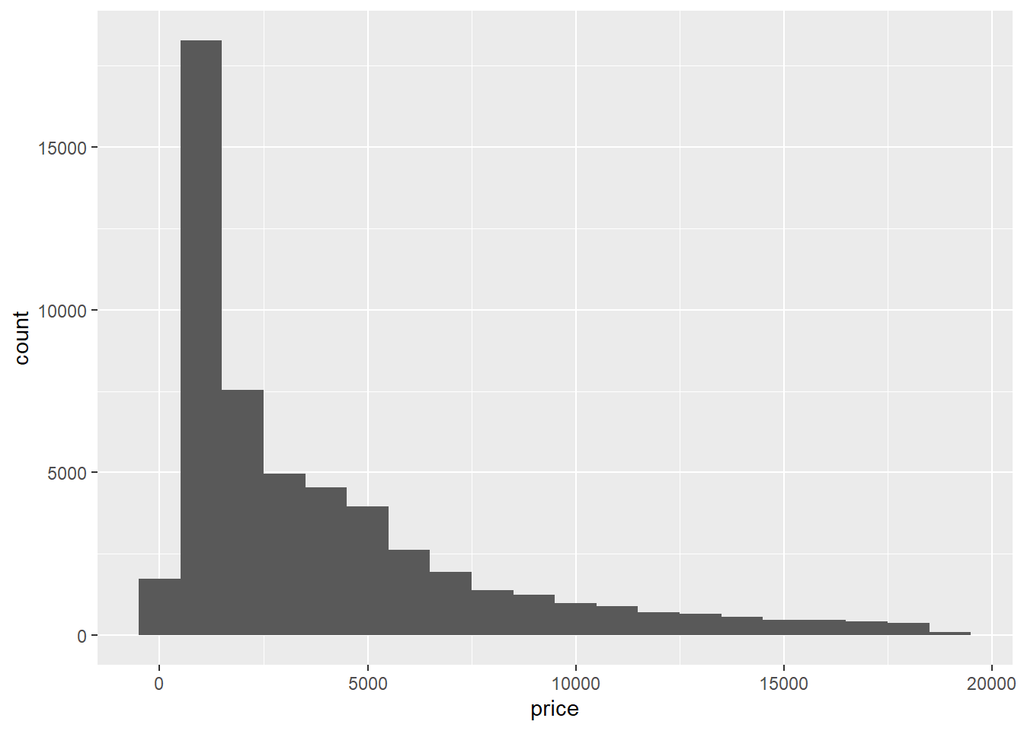

```r
price <- ggplot(data = diamonds, mapping = aes(x = price))
price + geom_histogram(binwidth = 1000)
```

binwidth를 1000으로 설정하여 매우 단순화한 히스토그램을 그려보았을 때, 오른쪽 꼬리 분포를 보임을 확인할 수 있었습니다.

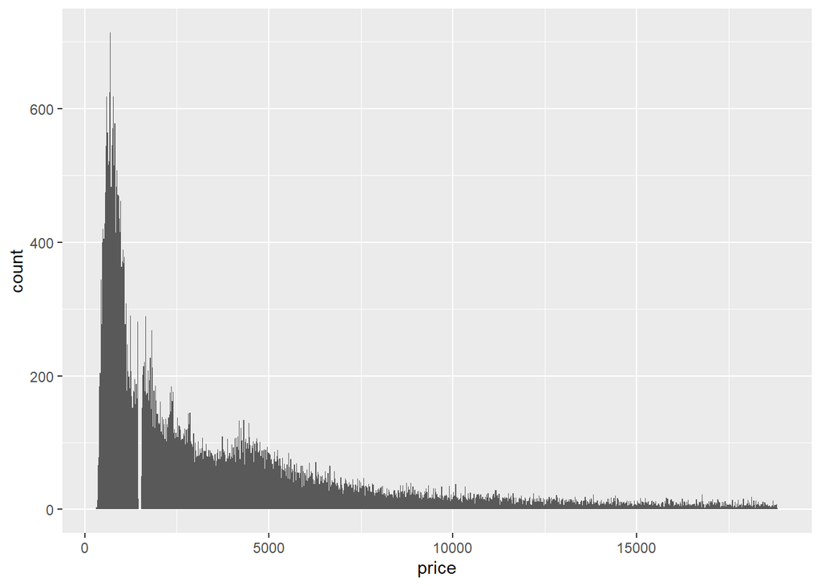

```r
price + geom_histogram(binwidth = 20)
```

binwidth를 20으로 설정하고 히스토그램을 그렸을 때, 많은 spike를 관측할 수 있었고 5000보다 작은 값에 치우져져 있는 걸 확인할 수 있습니다.

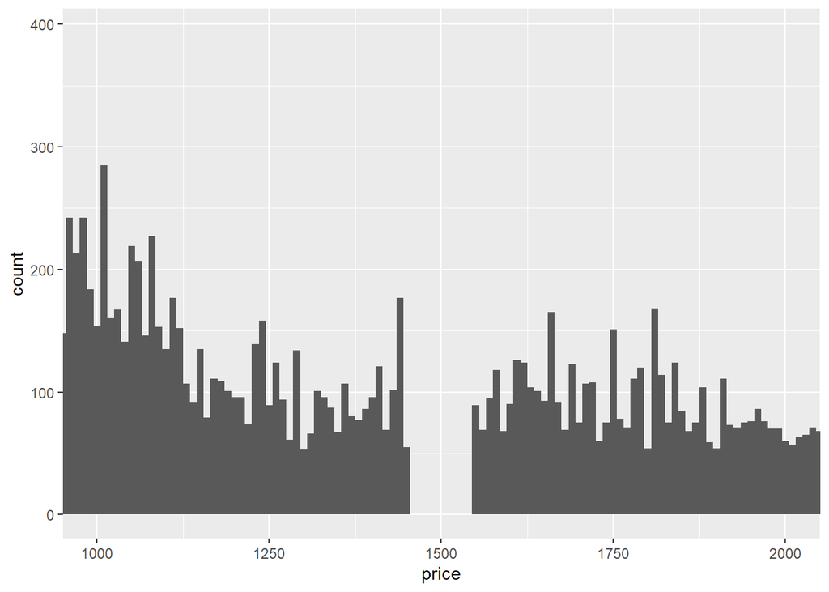

```r
price + geom_histogram(binwidth = 10) + coord_cartesian(xlim = c(1000, 2000))
```

가격을 1000~2000만 그려보았을 때, 1500$ 부근에는 아예 값이 없는 것을 확인 할 수 있었습니다.

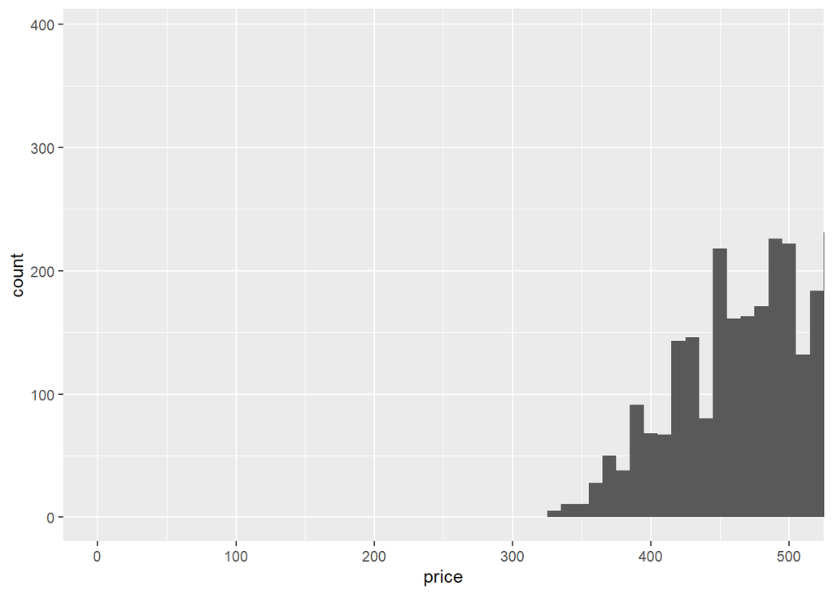

```r
price + geom_histogram(binwidth = 10) + coord_cartesian(xlim = c(0, 500))
```

또한, 300$ 이하의 다이아몬드도 없음을 확인할 수 있었습니다.

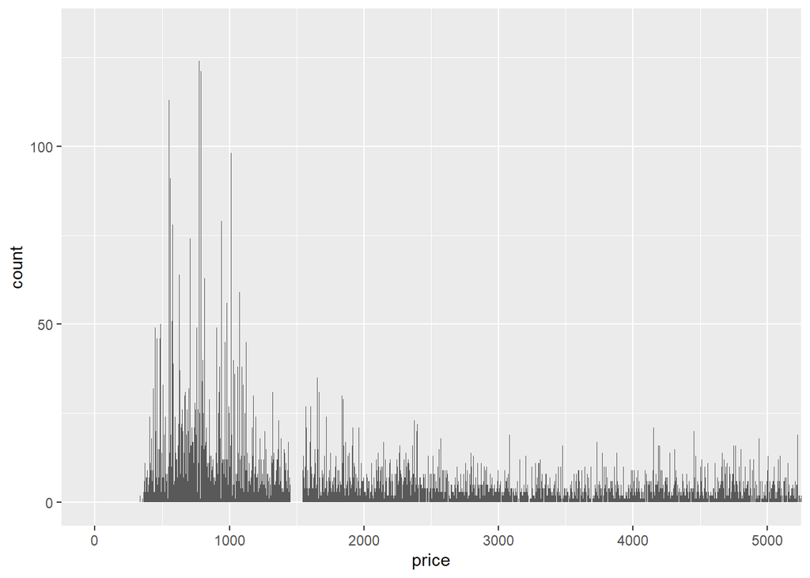

```r
price + geom_histogram(binwidth = 1) + coord_cartesian(xlim = c(0, 5000))
```

binwidth를 1까지 낮추었을 때, spike가 극단적이게 그려지는 것을 확인 할 수 있었습니다. 다이아몬드를 판매하는 특정 가격들이 정해져 있다고 생각할 수 있습니다.